# Object Data Over CAN Users Guide

# Overview

This lab exercise demonstrates the ability of AWR1642 TI-mmWave sensor to estimate and track the position (in the azimuthal plane), the velocity of objects and sends the detections over CAN interface.

The mmWave sensor AWR1642BOOST ES 2.0 is used for lab demonstration.

# Required Hardware

- AWR1642BOOST ES 2.0
- CAN adapter such as [PCAN-USBFD](https://www.peak-system.com/PCAN-USB-FD.365.0.html?&L=1) to receive data on PC.
- Simple CAN BUS circuit board to connect multiple CAN lines on same bus.
- [5v/>2.5A Power Supply](https://www.digikey.com/en/products/detail/cuiinc/SMI36-5-V-P5/5415060) for AWR1642BOOST ES 2.0

# Getting Started

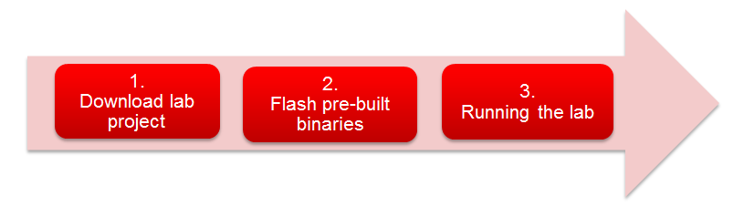

## Flash Lab Binaries on AWR1642BOOST

- Power on the EVM using a 5V/2.5A power supply.
- Connect the EVM to your PC and check the COM ports in Windows Device Manager
- The EVM exports two virtual COM ports as shown below:

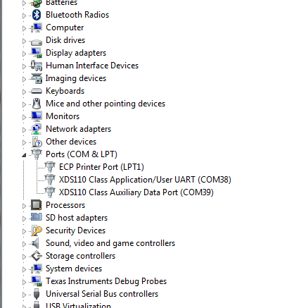

[output not shown]

- Note the COM<sub>UART</sub> and COM<sub>AUX</sub> port numbers, as they will be used later for flashing and running the Lab.
  - **COM<sub>UART</sub>:** COM38
  - **COM<sub>AUX</sub>:** COM39  
    The actual port numbers on your machine may be different
- Put the EVM in flashing mode by connecting jumpers on SOP0 and SOP2 as shown in the image.

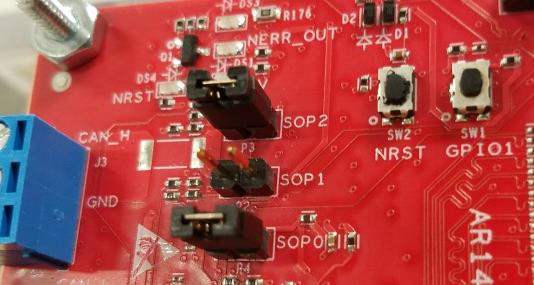

- Download and open the [**UniFlash**](https://www.ti.com/tool/UNIFLASH) tool
- In the **New Configuration** section, locate and select the appropriate device AWR1642BOOST.
- Click **Start** to proceed.

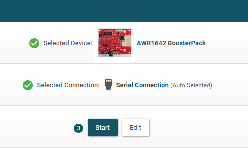

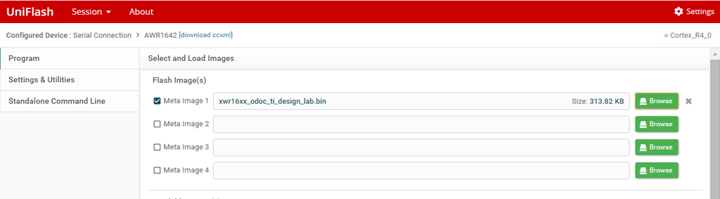

- In the **Settings & Utilities** tab, fill the **COM Port** text box with the Application/User UART COM port number **(COM<sub>UART</sub>)** noted earlier

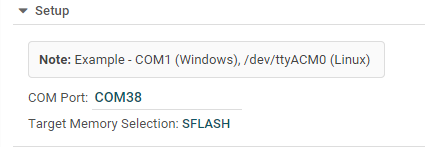

- Return to the **Program** tab, power cycle the device and click on **Load Images**
- When the flash procedure completes, UniFlash’s console should indicate: [SUCCESS] Program Load completed successfully
- Power off the board and remove the jumper from only header **SOP2** (this puts the board back in functional mode)

## Run the Lab

- Install XDS Emulation Package on the PC host if needed.
  - If CCS is installed on the PC host, the XDS Emulation package has already been installed during the CCS installation process.
- Execute the Demo GUI located in: `<TOOLBOX_INSTALL_DIR>\tools\visualizers\mmwave_can_visualizer`
  - The executable provided only works in a Windows operating system

CANBUS circuit:

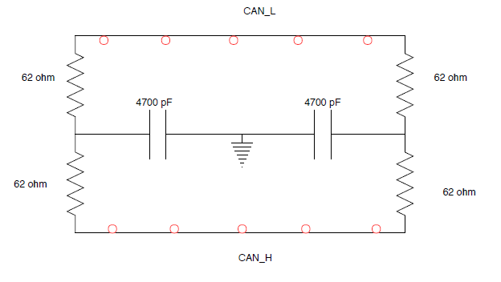

- Connect the CAN lines on the AWR1642BOOST to the CANBUS circuit.
- Connect the PCAN-USBFD CAN lines to the CANBUS circuit.

Pin assignment on the PCAN-USBFD:

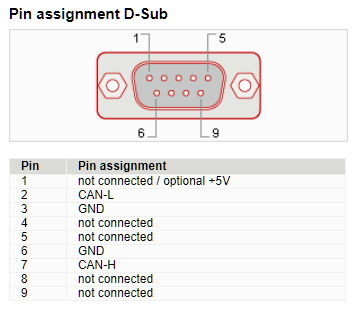

**Note: The AWR1642BOOST has only 1 CANFD so there is no need to use the CANBUS circuit. The CAN lines can be connected directly to PCAN-USBFD. If there are multiple AWR1642BOOST then use the CANBUS circuit.**

[figure not shown]

- Check that PCAN-USBFD is connected to the PC host running the application.
- Open the MMWAVECANVisualizer.exe
  - **Note: MMWAVECANVisualizer.exe is developed based on the SDK(pcan-basic.zip) from Peak-System for the PCAN-USBFD**

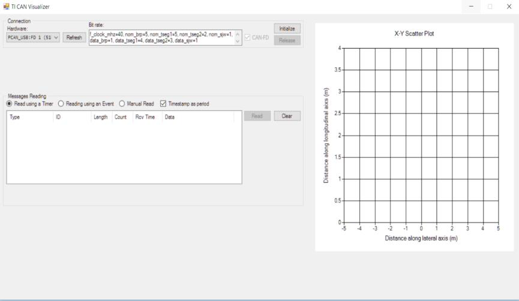

- Initialize the PCAN-USBFD

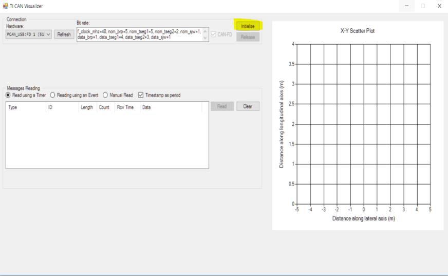

- Turn ON the AWR1642BOOST that is flashed with the image. The point cloud should be seen on the X-Y scatter plot. CAN messages are seen in the “Messages Reading” Window.

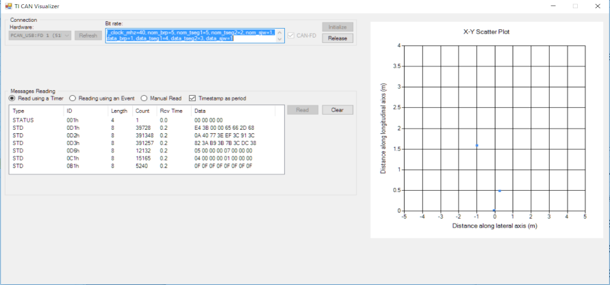